# Covid-19 infección en Ecuador. Modelos matemáticos y predicciones

Una comparación de modelos, lineal, polilnomico,logísticos y exponenciales aplicados a la infección por el virus Covid-19

Se crea modelos de series temporales del número total de personas infectadas hasta la fecha (es decir, las personas realmente infectadas más las personas que han sido infectadas). Estos modelos tienen parámetros , que se estimarán por ajuste de curva.

```python
# Importar las librerias para el analasis
import pandas as pd
import numpy as np
from datetime import datetime,timedelta
from sklearn.metrics import mean_squared_error
from scipy.optimize import curve_fit
from scipy.optimize import fsolve
from sklearn import linear_model
import matplotlib.pyplot as plt
%matplotlib inline
```

```python
# Actualizar los datos (URL)

url = 'https://covid.ourworldindata.org/data/ecdc/full_data.csv'

df = pd.read_csv(url)
df
```

|  | date | location | new_cases | new_deaths | total_cases | total_deaths |
| --- | --- | --- | --- | --- | --- | --- |
| 0 | 2019-12-31 | Afghanistan | 0 | 0 | 0 | 0 |
| 1 | 2020-01-01 | Afghanistan | 0 | 0 | 0 | 0 |
| 2 | 2020-01-02 | Afghanistan | 0 | 0 | 0 | 0 |
| 3 | 2020-01-03 | Afghanistan | 0 | 0 | 0 | 0 |
| 4 | 2020-01-04 | Afghanistan | 0 | 0 | 0 | 0 |
| 5 | 2020-01-05 | Afghanistan | 0 | 0 | 0 | 0 |
| 6 | 2020-01-06 | Afghanistan | 0 | 0 | 0 | 0 |
| 7 | 2020-01-07 | Afghanistan | 0 | 0 | 0 | 0 |
| 8 | 2020-01-08 | Afghanistan | 0 | 0 | 0 | 0 |
| 9 | 2020-01-09 | Afghanistan | 0 | 0 | 0 | 0 |
| 10 | 2020-01-10 | Afghanistan | 0 | 0 | 0 | 0 |
| 11 | 2020-01-11 | Afghanistan | 0 | 0 | 0 | 0 |
| 12 | 2020-01-12 | Afghanistan | 0 | 0 | 0 | 0 |
| 13 | 2020-01-13 | Afghanistan | 0 | 0 | 0 | 0 |
| 14 | 2020-01-14 | Afghanistan | 0 | 0 | 0 | 0 |
| 15 | 2020-01-15 | Afghanistan | 0 | 0 | 0 | 0 |
| 16 | 2020-01-16 | Afghanistan | 0 | 0 | 0 | 0 |
| 17 | 2020-01-17 | Afghanistan | 0 | 0 | 0 | 0 |
| 18 | 2020-01-18 | Afghanistan | 0 | 0 | 0 | 0 |
| 19 | 2020-01-19 | Afghanistan | 0 | 0 | 0 | 0 |
| 20 | 2020-01-20 | Afghanistan | 0 | 0 | 0 | 0 |
| 21 | 2020-01-21 | Afghanistan | 0 | 0 | 0 | 0 |
| 22 | 2020-01-22 | Afghanistan | 0 | 0 | 0 | 0 |
| 23 | 2020-01-23 | Afghanistan | 0 | 0 | 0 | 0 |
| 24 | 2020-01-24 | Afghanistan | 0 | 0 | 0 | 0 |
| 25 | 2020-01-25 | Afghanistan | 0 | 0 | 0 | 0 |
| 26 | 2020-01-26 | Afghanistan | 0 | 0 | 0 | 0 |
| 27 | 2020-01-27 | Afghanistan | 0 | 0 | 0 | 0 |
| 28 | 2020-01-28 | Afghanistan | 0 | 0 | 0 | 0 |
| 29 | 2020-01-29 | Afghanistan | 0 | 0 | 0 | 0 |
| ... | ... | ... | ... | ... | ... | ... |
| 9583 | 2020-03-29 | Zambia | 12 | 0 | 28 | 0 |
| 9584 | 2020-03-30 | Zambia | 1 | 0 | 29 | 0 |
| 9585 | 2020-03-31 | Zambia | 6 | 0 | 35 | 0 |
| 9586 | 2020-04-01 | Zambia | 0 | 0 | 35 | 0 |
| 9587 | 2020-04-02 | Zambia | 1 | 0 | 36 | 0 |
| 9588 | 2020-04-03 | Zambia | 3 | 1 | 39 | 1 |
| 9589 | 2020-04-04 | Zambia | 0 | 0 | 39 | 1 |
| 9590 | 2020-04-05 | Zambia | 0 | 0 | 39 | 1 |
| 9591 | 2020-04-06 | Zambia | 0 | 0 | 39 | 1 |
| 9592 | 2020-04-07 | Zambia | 0 | 0 | 39 | 1 |
| 9593 | 2020-04-08 | Zambia | 0 | 0 | 39 | 1 |
| 9594 | 2020-03-21 | Zimbabwe | 1 | 0 | 1 | 0 |
| 9595 | 2020-03-22 | Zimbabwe | 1 | 0 | 2 | 0 |
| 9596 | 2020-03-23 | Zimbabwe | 0 | 0 | 2 | 0 |
| 9597 | 2020-03-24 | Zimbabwe | 0 | 1 | 2 | 1 |
| 9598 | 2020-03-25 | Zimbabwe | 0 | 0 | 2 | 1 |
| 9599 | 2020-03-26 | Zimbabwe | 1 | 0 | 3 | 1 |
| 9600 | 2020-03-27 | Zimbabwe | 0 | 0 | 3 | 1 |
| 9601 | 2020-03-28 | Zimbabwe | 2 | 0 | 5 | 1 |
| 9602 | 2020-03-29 | Zimbabwe | 2 | 0 | 7 | 1 |
| 9603 | 2020-03-30 | Zimbabwe | 0 | 0 | 7 | 1 |
| 9604 | 2020-03-31 | Zimbabwe | 0 | 0 | 7 | 1 |
| 9605 | 2020-04-01 | Zimbabwe | 1 | 0 | 8 | 1 |
| 9606 | 2020-04-02 | Zimbabwe | 0 | 0 | 8 | 1 |
| 9607 | 2020-04-03 | Zimbabwe | 0 | 0 | 8 | 1 |
| 9608 | 2020-04-04 | Zimbabwe | 1 | 0 | 9 | 1 |
| 9609 | 2020-04-05 | Zimbabwe | 0 | 0 | 9 | 1 |
| 9610 | 2020-04-06 | Zimbabwe | 0 | 0 | 9 | 1 |
| 9611 | 2020-04-07 | Zimbabwe | 0 | 0 | 9 | 1 |
| 9612 | 2020-04-08 | Zimbabwe | 1 | 0 | 10 | 1 |

9613 rows × 6 columns

Imprimos los resultados y agregamos el numero del dia

```python
df = df[df['location'].isin(['Ecuador'])] #Filtro la Informacion solo para Ecuador
df2 = df[df['total_cases'] >= 1]
df2 = df2.loc[:,['date', 'total_cases' ]] #Selecciono las columnas de analasis


# Expresar las fechas en numero de dias desde el 01 Enero
FMT = '%Y-%m-%d'
date = df2['date']
df2['date'] = date.map(lambda x : (datetime.strptime(x, FMT) - datetime.strptime("2020-01-01", FMT)).days)

df2
```

|  | date | total_cases |
| --- | --- | --- |
| 2575 | 60 | 1 |
| 2576 | 61 | 6 |
| 2577 | 62 | 7 |
| 2578 | 64 | 10 |
| 2579 | 65 | 13 |
| 2580 | 68 | 14 |
| 2581 | 69 | 15 |
| 2582 | 70 | 17 |
| 2583 | 73 | 23 |
| 2584 | 74 | 28 |
| 2585 | 75 | 37 |
| 2586 | 76 | 58 |
| 2587 | 77 | 111 |
| 2588 | 78 | 168 |
| 2589 | 79 | 199 |
| 2590 | 80 | 426 |
| 2591 | 81 | 532 |
| 2592 | 82 | 789 |
| 2593 | 83 | 981 |
| 2594 | 84 | 1082 |
| 2595 | 85 | 1211 |
| 2596 | 86 | 1403 |
| 2597 | 87 | 1627 |
| 2598 | 88 | 1835 |
| 2599 | 89 | 1890 |
| 2600 | 90 | 1966 |
| 2601 | 91 | 2302 |
| 2602 | 92 | 2758 |
| 2603 | 93 | 3163 |
| 2604 | 94 | 3368 |
| 2605 | 95 | 3465 |
| 2606 | 96 | 3646 |
| 2607 | 97 | 3747 |
| 2608 | 98 | 3995 |

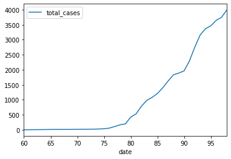

```python
df2.plot(x ='date', y='total_cases')
```

## EL modelo lineal

La regresión lineal es un algoritmo de aprendizaje supervisado que se utiliza en Machine Learning y en estadística. En su versión más sencilla, lo que haremos es «dibujar una recta» que nos indicará la tendencia de un conjunto de datos continuos.

Recordemos rápidamente la fórmula de la recta:

Y = mX + b

Donde Y es el resultado, X es la variable, m la pendiente (o coeficiente) de la recta y b la constante o también conocida como el «punto de corte con el eje Y» en la gráfica (cuando X=0) Ejemplo

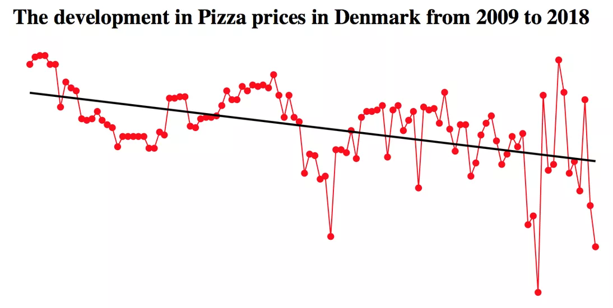

Recordemos que los algoritmos de Machine Learning Supervisados, aprenden por sí mismos y -en este caso- a obtener automáticamente esa «recta» que buscamos con la tendencia de predicción. Para hacerlo se mide el error con respecto a los puntos de entrada y el valor «Y» de salida real.

```python
x = list(df2.iloc [:, 0]) # Fecha
y = list(df2.iloc [:, 1]) # Numero de casos
# Creamos el objeto de Regresión Lineal

regr = linear_model.LinearRegression()

# Entrenamos nuestro modelo
regr.fit(np.array(x).reshape(-1, 1) ,y)

# Veamos los coeficienetes obtenidos, En nuestro caso, serán la Tangente
print('Coefficients: \n', regr.coef_)
# Este es el valor donde corta el eje Y (en X=0)
print('Independent term: \n', regr.intercept_)
# Error Cuadratico Medio
```

```
Coefficients:
 [108.02574204]
Independent term:
 -7509.223078878253
```

De la ecuación de la recta y = mX + b nuestra pendiente «m» es el coeficiente y el término independiente «b»

```python
#Vamos a comprobar:
# Quiero predecir cuántos "Casos" voy a obtener p en el dia 100,
# según nuestro modelo, hacemos:
y_prediccion = regr.predict([[200]])
print(int(y_prediccion))
```

```
14095
```

```
[ 50  51  52  53  54  55  56  57  58  59  60  61  62  63  64  65  66  67
  68  69  70  71  72  73  74  75  76  77  78  79  80  81  82  83  84  85
  86  87  88  89  90  91  92  93  94  95  96  97  98  99 100 101 102 103
 104 105 106 107 108 109 110 111 112 113 114 115 116 117 118 119 120 121
 122 123 124 125 126 127 128 129 130 131 132 133 134 135 136 137 138 139
 140 141 142 143 144 145 146 147 148 149]
```

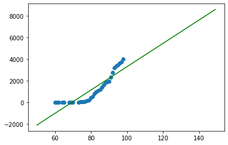

```python
#Graficar
plt.scatter(x, y)
x_real = np.array(range(50, 150))
print(x_real)
plt.plot(x_real, regr.predict(x_real.reshape(-1, 1)), color='green')
plt.show()
```

## El modelo logistico

A continuacion se puede apreciar un ejemplo de regresion logistica

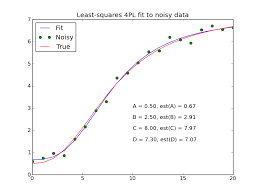

```python
def modelo_logistico(x,a,b):
    return a+b*np.log(x)

exp_fit = curve_fit(modelo_logistico,x,y) #Extraemos los valores de los paramatros
print(exp_fit)
```

```
(array([-34418.67022651,   8132.28071562]), array([[13422661.74559064, -3061149.82290768],
       [-3061149.82290768,   698853.09802797]]))
```

## Graficas

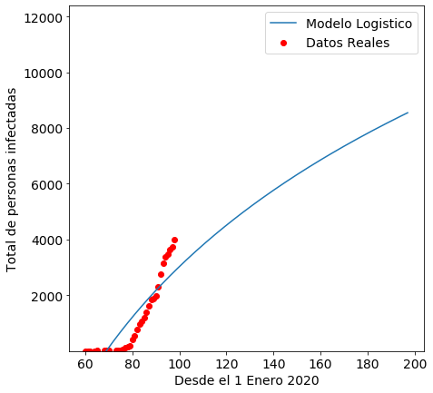

```python
pred_x = list(range(min(x),max(x)+100)) # Predecir 50 dias mas
plt.rcParams['figure.figsize'] = [7, 7]
plt.rc('font', size=14)
# Real data
plt.scatter(x,y,label="Datos Reales",color="red")
# Predicted exponential curve
plt.plot(pred_x, [modelo_logistico(i,exp_fit[0][0],exp_fit[0][1]) for i in pred_x], label="Modelo Logistico" )
plt.legend()
plt.xlabel("Desde el 1 Enero 2020")
plt.ylabel("Total de personas infectadas")
plt.ylim((min(y)*0.9,max(y)*3.1)) # Definir los limites de Y
plt.show()
```

## Modelo exponencial

Mientras que el modelo logístico describe un crecimiento de infección que se detendrá en el futuro, el modelo exponencial describe un crecimiento de infección imparable . Por ejemplo, si un paciente infecta a 2 pacientes por día, después de 1 día tendremos 2 infecciones, 4 después de 2 días, 8 después de 3 y así sucesivamente.

A continuacion se tiene un ejemplo de regresion exponencial

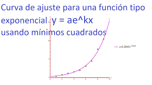

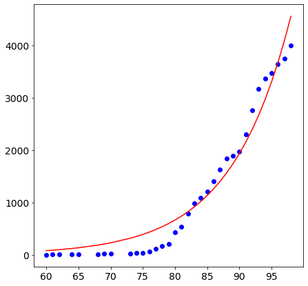

```
La proyeccion a 100 dias es igual a:   5646.3105414845695
```

```python
# Implementar
x1 = np.array(x, dtype=float) #transformo mi array de datos a floats
y1 = np.array(y, dtype=float)

def mod_exponencial(x, a, b): #funcion que permite realizar la regrecion con el modelo exponencial
    return a * np.exp(b * x)

popt, pcov = curve_fit(mod_exponencial, x1, y1, p0=(0,0.1))

#Grfica del modelo exponencial

plt.plot(x1, y1, 'bo',label="Original Data")
plt.plot(x1, mod_exponencial(x1,*popt),color='red')
plt.show()

pro_x = mod_exponencial(100,*popt)
print("La proyeccion a 100 dias es igual a:  ", pro_x)
```

## Modelo polinomial

Predicción de una variable de respuesta cuantitativa a partir de una variable predictora cuantitativa, donde la relación se modela como una función polinomial de orden n (esto significa que pueden tener de diferentes exponenciales o grados y se debe ir probando)

Se puede tener una ecuacion con diferentes grados

y = a0 + a1x + a2x^2 + a3x^3 + … + anx^n + ε

Ejemplo de una regresion polinomica de grado 4.

[figure not shown]

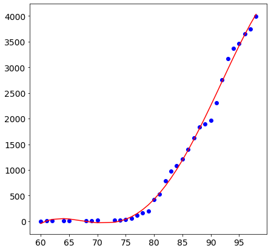

```
La proyeccion a 100 dias es igual a:   4353.051704629208
```

```python
# Implementar

x2 = np.array(x, dtype=float)
y2 = np.array(y, dtype=float)

def func_polinomial(x, a, b, c, d, e):
    return a*x**4 + b*x**3 + c*x**2 + d*x + e

popt1, pcov1 = curve_fit(func_polinomial, x2, y2)
#print ("a = %s , b = %s, c = %s, d = %s, e = %s" % (popt1[0], popt1[1], popt1[2], popt1[3], popt1[4]))

plt.plot(x2, y2, 'bo',label="Datos Originales")
plt.plot(x2, func_polinomial(x2, *popt1), color = 'red')
plt.show()

pro_x1 = func_polinomial(100,*popt1)
print("La proyeccion a 100 dias es igual a:  ", pro_x1)
# Se puede implementar modelos adicionales, en caso de ser asi explicar o dar una introduccion del modelo aplicado

# Se tomara como puntos adicionales al trabajo.
```

## Analisis

El analisis respecto a las graficas realizadas con lenguaje python se puede observar que tanto la exponencial como la polinomial son sos modelos que permiten realizar un mejor acercamiento a los casos de invectados con los que cueta ele ecuador, mediante estos datos se puede hacer una prdiccion a cien dias para saber cuanto es la curva de crecimiento que se presentara a futuro, mediante estas predicciones puedo afirmar que es mucho mas exacto para el problema utilizar el modelo polinomial de cuarto orden ya que es el que mejor acercamiento en la grafica frente a los puntos planteados por nuestro dataset.  
En cuanto a la tarea fue necesario aprender e investugar los conseptos basicos del fuancionamiento de cada una de las funciones que nos permiten realizar los modelos de regresion de igual manera el revisar las informacion que nos proporciono el Docente ya que mediante ejemplos e informacion adicional se puede completar dicha tara.

## Criterio personal (politico, economico y social de la situacion)

Como criterio personal podo aportar que este tema de la pandemia COVID19 esta afectando mucho al pais en muchos areas ocampos como son el politico, el academico, el economico, el social y pues la parta humana de cada una de las familias que tiene asus seres queridos ya sea como casos positivos o desesos a causa del COVID.  
En el area politica se uede observar que las personas que estan al frente de nuestro pais han demostrado mno tener la capacidad para afrontar esta cris de ai el porque hasta el dia de hoy las cifras de infectados y muertes aun siguen incrementando.  
En el area economica pues es mas que obvio que nos vemos afectados ya que muchas de las actividades economicas del pais se ven obligados a cerrar por el temor a contraer el virus.  
En area academica tambien se ven un panorama muy poco alentador ya que es muy complicado que mucho de nuestros jovene o niños de primaria puedan adaptarce a las altermnativas tecnologicas para continuar con sus estudios, atrasando asi su aprendizaje.  
Por ultimo pues la parte sociales la familiar es la mas afectada ya que para muchos fue impocible regresae a sus provicias para estar junto a sus familiares, y pues elmismo hecho de contar con un toque de queda hace que sea impocible que las personas se puedan relacionar como nommalmete se suele hacer para poder cumplic con sus funciones lavorales o funciones cotidianas para llevar el sustento ha su hogar.

# Referencias

- https://www.researchgate.net/publication/340092755_Infeccion_del_Covid-19_en_Colombia_Una_comparacion_de_modelos_logisticos_y_exponenciales_aplicados_a_la_infeccion_por_el_virus_en_Colombia
- https://www.aprendemachinelearning.com/regresion-lineal-en-espanol-con-python/